# 607-Group-Project-3

Steve Phillips, Dirk Hartog, Lwin Shwe

2023-10-13

### Probem Statement

This is a project for all the members of an assigned group to work on together, since being able to work effectively on a virtual team is a key “soft skill” for data scientists. Use data to answer the question, “Which are the most valued data science skills?” Please note especially the requirement about making a presentation during the class meetup on the following Wednesday.

Effective communication skill is essential for data scientists, and the ability to communicate the findings to team and explain what value these insights can bring to technical or non-technical stakeholders also are very important. Curiosity is a trait that makes data science more interesting and beneficial. Being curious about business problems will let you to the solution as well. Team works in a team setting and being a team player is critical. We should always listen to their team members for their input and take into consideration to work as a team.

```r
library(RCurl)
library(kableExtra)
library(DBI)
library(RMySQL)
library(RODBC)
conn <- dbConnect(MySQL(), user= "root", password = "M2max2023", dbname='MyDB1', host='localhost', port=3306)
```

### Load realational database from MySQL Workbench to R

```r
library(dplyr)
```

```r
library(ggplot2)
cryto_dbms <- dbGetQuery(conn , "select theDate,opening, opening, highest, lowest, closing, volume, marketcap, DailyPrice.CoinSymbol, coalesce(CoinDesc,'') CoinDesc
from DailyPrice
left join CoinList
on DailyPrice.CoinSymbol = CoinList.CoinSymbol")
glimpse(cryto_dbms)
```

```
## Rows: 17,333
## Columns: 10
## $ theDate    <chr> "2013-04-01", "2013-05-01", "2013-06-01", "2013-07-01", "20…
## $ opening    <dbl> 135.300003, 139.000000, 128.815002, 97.510002, 106.212997, …
## $ opening    <dbl> 135.300003, 139.000000, 128.815002, 97.510002, 106.212997, …
## $ highest    <dbl> 147.48801, 139.89000, 129.78000, 111.34400, 140.89000, 146.…
## $ lowest     <dbl> 132.100006, 79.099998, 88.500000, 65.526001, 101.210999, 11…
## $ closing    <dbl> 139.000000, 129.000000, 96.613998, 106.089996, 135.350006, …
## $ volume     <dbl> 0, 0, 0, 0, 0, 0, 619926, 673892, 784439, 663994, 5847500, …
## $ marketcap  <dbl> 1542813125, 1447870200, 1096957771, 1218777834, 1574672051,…
## $ CoinSymbol <chr> "BTC", "BTC", "BTC", "BTC", "BTC", "BTC", "ETH", "ETH", "ET…
## $ CoinDesc   <chr> "Bitcoin", "Bitcoin", "Bitcoin", "Bitcoin", "Bitcoin", "Bit…
```

```r
# Export the data frame to a CSV file local directory
write.csv(cryto_dbms, "DATA 607 Group Project3.csv", row.names = FALSE)
#Read the .csv file
cryptocurrencies <- read.csv("DATA 607 Group Project3.csv")
head(cryptocurrencies)
```

```
##      theDate opening opening.1 highest  lowest closing volume  marketcap
## 1 2013-04-01 135.300   135.300 147.488 132.100 139.000      0 1542813125
## 2 2013-05-01 139.000   139.000 139.890  79.100 129.000      0 1447870200
## 3 2013-06-01 128.815   128.815 129.780  88.500  96.614      0 1096957771
## 4 2013-07-01  97.510    97.510 111.344  65.526 106.090      0 1218777834
## 5 2013-08-01 106.213   106.213 140.890 101.211 135.350      0 1574672051
## 6 2013-09-01 135.140   135.140 146.500 118.460 133.000      0 1566038425
##   CoinSymbol CoinDesc
## 1        BTC  Bitcoin
## 2        BTC  Bitcoin
## 3        BTC  Bitcoin
## 4        BTC  Bitcoin
## 5        BTC  Bitcoin
## 6        BTC  Bitcoin
```

```r
total_volume_in_month <- dbGetQuery(conn, "select theMonth, CoinSymbol, sum(volume) TotalVolumeInMonth
from
(
select monthname(theDate) theMonth, CoinSymbol, volume
from DailyPrice
where year(theDate) = 2021 and CoinSymbol in ('ADA', 'ETH')
) A
group by theMonth, CoinSymbol;")
total_volume_in_month
```

```
##     theMonth CoinSymbol TotalVolumeInMonth
## 1    January        ADA       1.822667e+11
## 2   February        ADA       2.426997e+11
## 3      March        ADA       1.675218e+11
## 4      April        ADA       1.262510e+11
## 5        May        ADA       2.257907e+11
## 6       June        ADA       9.218966e+10
## 7       July        ADA       5.194009e+10
## 8     August        ADA       1.604260e+11
## 9  September        ADA       1.521636e+11
## 10   October        ADA       8.590928e+10
## 11  November        ADA       7.988261e+10
## 12  December        ADA       5.562197e+10
## 13   January        ETH       2.224801e+12
## 14  February        ETH       1.007718e+12
## 15     March        ETH       7.308322e+11
## 16     April        ETH       9.953342e+11
## 17       May        ETH       1.510330e+12
## 18      June        ETH       8.135231e+11
## 19      July        ETH       6.299535e+11
## 20    August        ETH       7.502077e+11
## 21 September        ETH       6.539849e+11
## 22   October        ETH       5.747985e+11
## 23  November        ETH       5.735468e+11
## 24  December        ETH       6.210420e+11
```

```r
cryptocurrencies %>%
count(CoinSymbol) # count number of coins types
```

```
##    CoinSymbol    n
## 1         ADA   71
## 2       ALEPH 1201
## 3        ALGO  225
## 4         APT  368
## 5          AR  173
## 6       AUDIO  155
## 7        AVAX  160
## 8         AXL   55
## 9         BCH   74
## 10       BICO   97
## 11        BNB   74
## 12        BTC    6
## 13      BTRST  109
## 14        CCD   87
```

[output cut: 58 more lines]

```r
summary(cryto_dbms)
```

```
##    theDate             opening            opening            highest
##  Length:17333       Min.   :   0.000   Min.   :   0.000   Min.   :    0.000
##  Class :character   1st Qu.:   0.159   1st Qu.:   0.159   1st Qu.:    0.174
##  Mode  :character   Median :   0.849   Median :   0.849   Median :    0.927
##                     Mean   :  19.357   Mean   :  19.357   Mean   :   24.979
##                     3rd Qu.:   4.454   3rd Qu.:   4.454   3rd Qu.:    4.792
##                     Max.   :4623.679   Max.   :4623.679   Max.   :29455.032
##      lowest            closing             volume            marketcap
##  Min.   :   0.000   Min.   :   0.000   Min.   :0.000e+00   Min.   :0.000e+00
##  1st Qu.:   0.146   1st Qu.:   0.158   1st Qu.:1.440e+06   1st Qu.:1.313e+07
##  Median :   0.772   Median :   0.845   Median :8.988e+06   Median :5.311e+07
##  Mean   :  16.361   Mean   :  19.391   Mean   :1.966e+09   Mean   :1.446e+09
##  3rd Qu.:   4.218   3rd Qu.:   4.446   3rd Qu.:9.791e+07   3rd Qu.:3.538e+08
##  Max.   :3933.506   Max.   :4631.479   Max.   :2.225e+12   Max.   :5.491e+11
##   CoinSymbol          CoinDesc
##  Length:17333       Length:17333
##  Class :character   Class :character
##  Mode  :character   Mode  :character
##
##
##
```

```r
filter(cryptocurrencies,CoinSymbol == "ADA", theDate == "2023-09-13")
```

```
##  [1] theDate    opening    opening.1  highest    lowest     closing
##  [7] volume     marketcap  CoinSymbol CoinDesc
## <0 rows> (or 0-length row.names)
```

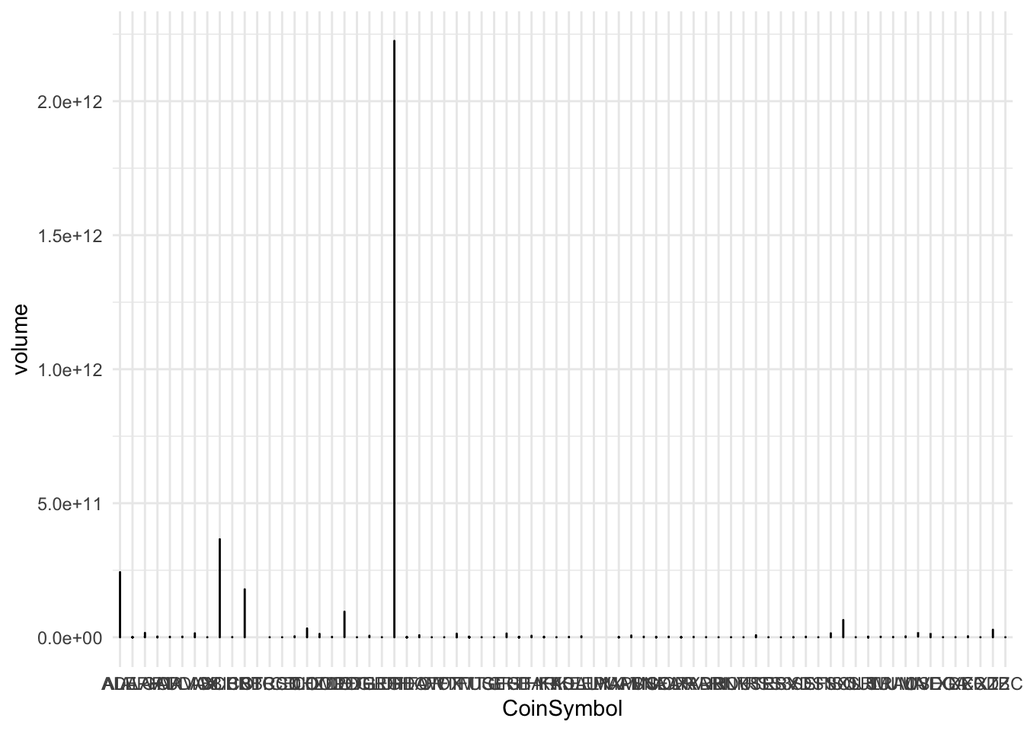

```r
# Create the line graph
ggplot(cryptocurrencies, aes(x = CoinSymbol, y = volume, group = CoinSymbol)) +
  geom_line() +
  labs(x = "CoinSymbol", y = "volume") +
  theme_minimal()
```

```r
# Checking for missing values
missing_values <- sapply(cryptocurrencies, function(x) sum(is.na(x)))

# Display the columns with missing values
columns_with_missing <- names(missing_values[missing_values > 0])
print(columns_with_missing)
```

```
## character(0)
```

```r
# Display the number of missing values for each column
print(missing_values)
```

```
##    theDate    opening  opening.1    highest     lowest    closing     volume
##          0          0          0          0          0          0          0
##  marketcap CoinSymbol   CoinDesc
##          0          0          0
```

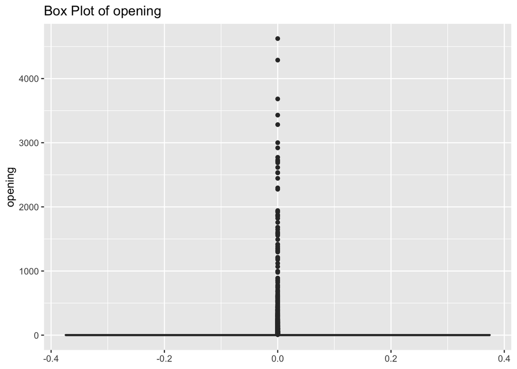

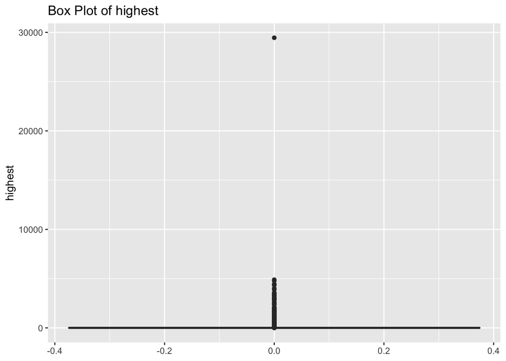

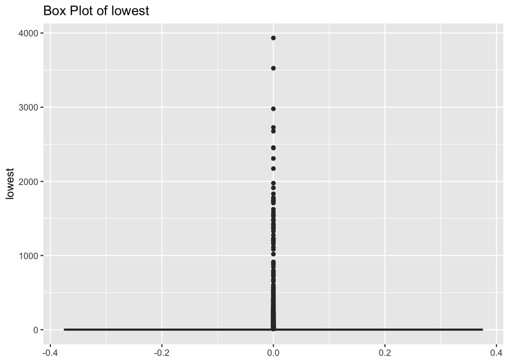

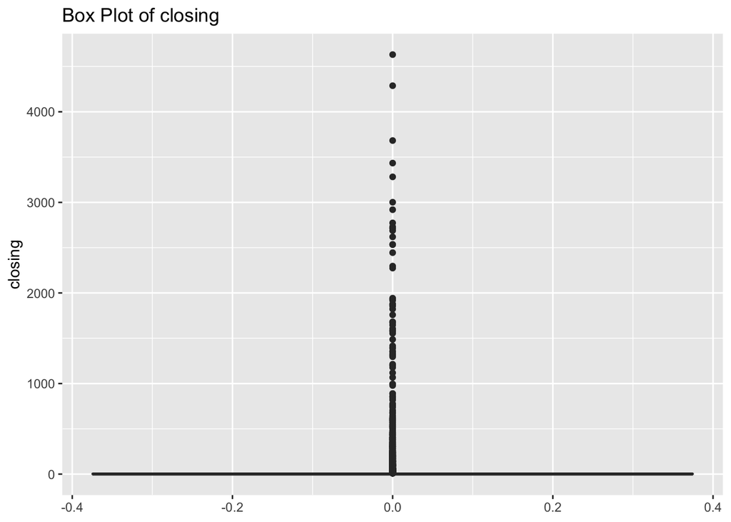

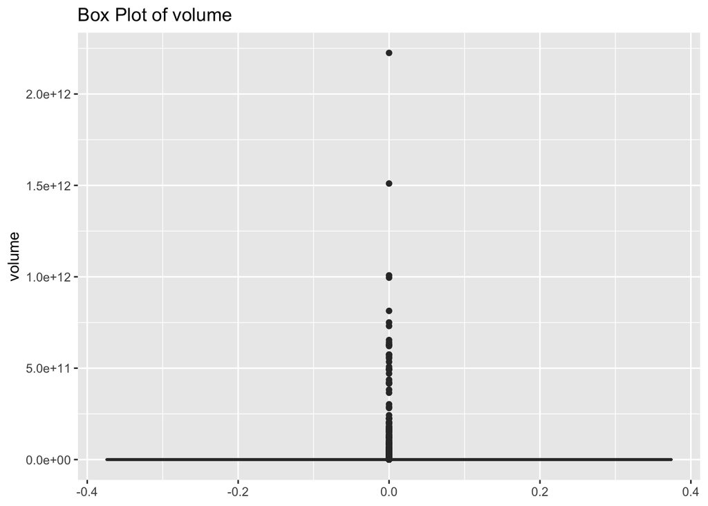

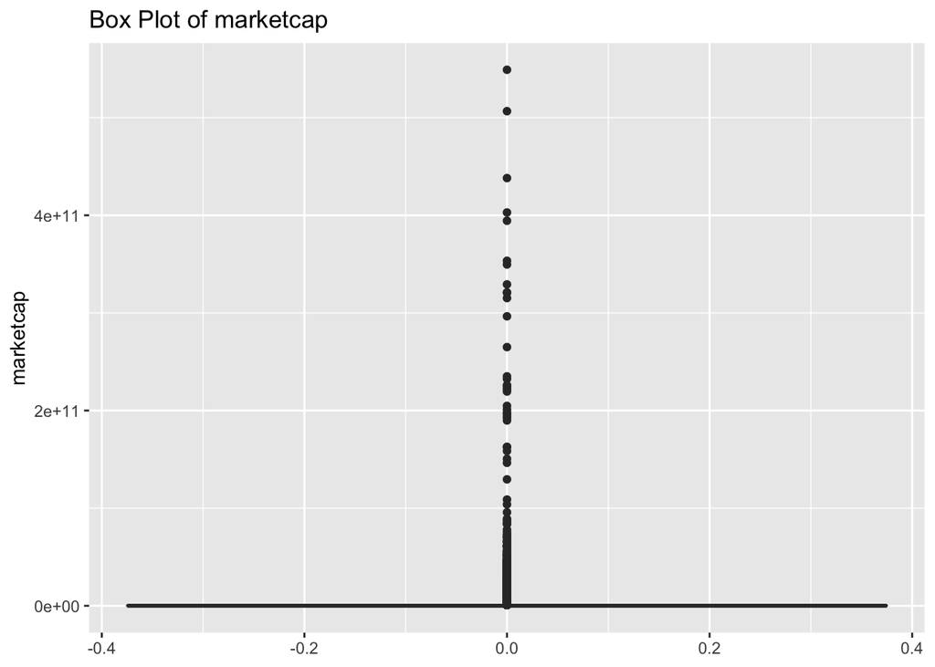

```r
# Create box plots for numeric columns that you want to check
numeric_columns <- cryptocurrencies %>%
  select(opening, highest, lowest, closing, volume, marketcap)

# Create a box plot for each numeric column
for (col in names(numeric_columns)) {
  p <- ggplot(cryptocurrencies, aes(y = !!sym(col))) +
    geom_boxplot() +
    labs(title = paste("Box Plot of", col))
  print(p)
}
```

```r
#Standardizing Dates
# Eg. Converting a date column to a standard format
cryptocurrencies$theDate <- as.Date(cryptocurrencies$theDate, format = "%Y-%m-%d")
head(cryptocurrencies$theDate)
```

```
## [1] "2013-04-01" "2013-05-01" "2013-06-01" "2013-07-01" "2013-08-01"
## [6] "2013-09-01"
```

```r
#Scaling Numerical Values
# Eg. Scaling the "volume" column
cryptocurrencies$volume <- scale(cryptocurrencies$volume)
head(cryptocurrencies$volume)
```

```
##             [,1]
## [1,] -0.06093914
## [2,] -0.06093914
## [3,] -0.06093914
## [4,] -0.06093914
## [5,] -0.06093914
## [6,] -0.06093914
```

```r
#Aggregating Data using (group_by)
# Example: Aggregating data by CryptoDesc and calculating the mean marketCap
aggregated_data <- cryptocurrencies %>%
  group_by(CoinSymbol) %>%
  summarize(mean_marketcap = mean(marketcap))
aggregated_data
```

```
## # A tibble: 72 × 2
##    CoinSymbol mean_marketcap
##    <chr>               <dbl>
##  1 ADA          15136333276.
##  2 ALEPH           15615850
##  3 ALGO          2354699926.
##  4 APT           1678899384.
##  5 AR             525243105.
##  6 AUDIO          345175118.
##  7 AVAX          7374312101.
##  8 AXL             96733602.
##  9 BCH           7664307663.
## 10 BICO           144179502.
## # ℹ 62 more rows
```